# Introduction

Celem niniejszego raportu jest przeprowadzenie kompleksowej analizy statystycznej drużyn Ekstraklasy w sezonie 2024/2025 w oparciu o dane pochodzące z serwisu FBref.com. W analizie wykorzystano zarówno podstawowe statystyki meczowe (gole zdobyte i stracone), jak i wskaźniki stylu gry oraz efektywności ofensywnej, które po oczyszczeniu i scaleniu posłużyły do dalszych badań. Kluczową częścią raportu jest analiza eksploracyjna (EDA), która poprzez wykresy i analizę korelacji pokazuje, że największy wpływ na liczbę punktów mają jakość strzałów i skuteczność wykończenia, a nie samo posiadanie piłki. Porównanie drużyn z czołówki, środka i dołu tabeli wskazuje, że zespoły z TOP4 wyróżniają się większą liczbą celnych strzałów i lepszym bilansem bramkowym, podczas gdy drużyny z dolnej części tabeli mają problemy z efektywnością ofensywną i defensywą. Zastosowany model regresji liniowej osiągnął wysokie R², co potwierdza, że statystyki ofensywne i defensywne dobrze wyjaśniają zdobycz punktową, choć ze względu na ograniczoną próbę analiza ma charakter głównie opisowy.

# 1. Data cleaning

```python
import pandas as pd

# Wczytanie konkretnego arkusza
df_table = pd.read_excel("../data/Dane_Ekstraklasa.xlsx",
                         sheet_name="Tabela_ligi_24_25",
                         engine="openpyxl")


df_table.head()
```

|  | Rk | Squad | MP | W | D | L | GF | GA | GD | Pts | Pts/MP | Attendance | Top Team Scorer | Goalkeeper | Notes |
| --- | --- | --- | --- | --- | --- | --- | --- | --- | --- | --- | --- | --- | --- | --- | --- |
| 0 | 1 | Lech Poznań | 34 | 22 | 4 | 8 | 68 | 31 | 37 | 70 | 2.06 | 28.947 | Mikael Ishak - 21 | Bartosz Mrozek | → Champions League via league finish |
| 1 | 2 | Raków | 34 | 20 | 9 | 5 | 51 | 23 | 28 | 69 | 2.03 | 5.427 | Jonatan Braut Brunes - 14 | Kacper Trelowski | → Conference League via league finish |
| 2 | 3 | Jagiellonia | 34 | 17 | 10 | 7 | 56 | 42 | 14 | 61 | 1.79 | 16.475 | Jesús Imaz - 16 | Sławomir Abramowicz | → Conference League via league finish |
| 3 | 4 | Pogoń Szczecin | 34 | 17 | 7 | 10 | 59 | 40 | 19 | 58 | 1.71 | 17.792 | Efthimis Koulouris - 28 | Valentin Cojocaru | NaN |
| 4 | 5 | Legia Warsaw | 34 | 15 | 9 | 10 | 60 | 45 | 15 | 54 | 1.59 | 24.691 | Marc Gual, Bartosz Kapustka - 9 | Kacper Tobiasz | → Europa League via cup win |

### Podstawowe czyszczenie

```python
df_table = df_table[df_table['Squad'].notna()].copy()
```

W kolumnie 'Squad' odflitrowywuje NaN albo „Total”

```python
# Poprawienie nazw drużyn
df_table['Squad'] = df_table['Squad'].str.extract(r'\[(.*?)\]', expand=False).fillna(df_table['Squad'])
df_table['Squad'] = df_table['Squad'].str.strip()

# Rzutowanie kolumn na typ numeryczny:
num_cols = ['Rk', 'MP', 'W', 'D', 'L', 'GF', 'GA', 'GD', 'Pts', 'Pts/MP', 'Attendance']
for col in num_cols:
    df_table[col] = pd.to_numeric(df_table[col], errors='coerce')
```

### Sprawdzenie braków danych:

```python
df_table.isna().sum()
```

```
Rk                  0
Squad               0
MP                  0
W                   0
D                   0
L                   0
GF                  0
GA                  0
GD                  0
Pts                 0
Pts/MP              0
Attendance          0
Top Team Scorer     0
Goalkeeper          0
Notes              11
dtype: int64
```

## Połączenie kilku akruszy

```python
# wczytanie dwóch arkuszy
std = pd.read_excel("../data/Dane_Ekstraklasa.xlsx",
                    sheet_name="Squad Standard Stats",
                    engine="openpyxl",
                    skiprows=1)

shoot = pd.read_excel("../data/Dane_Ekstraklasa.xlsx",
                      sheet_name="Squad Shooting",
                      engine="openpyxl",
                      skiprows=1)

# kolumna 'Squad' ma taką samą czystą postać jak w df_table
for df in [std, shoot]:
    df['Squad'] = df['Squad'].str.extract(r'\[(.*?)\]', expand=False).fillna(df['Squad'])
    df['Squad'] = df['Squad'].str.strip()

# tylko interesujące nas kolumny
std_small = std[['Squad', '# Pl', 'Age', 'Poss', 'Gls', 'Ast', 'G+A']].rename(
    columns={'Gls': 'Gls_std', 'Ast': 'Ast_std', 'G+A': 'G+A_std'}
)
shoot_small = shoot[['Squad', 'Gls', 'Sh', 'SoT', 'Sh/90', 'SoT/90', 'G/Sh', 'G/SoT']].rename(
    columns={'Gls': 'Gls_shoot'}
)

# Merge po nazwie drużyny
df = df_table.merge(std_small, on='Squad', how='left', suffixes=('', '_std'))
df = df.merge(shoot_small, on='Squad', how='left', suffixes=('', '_shoot'))

df.head()
```

|  | Rk | Squad | MP | W | D | L | GF | GA | GD | Pts | ... | Gls_std | Ast_std | G+A_std | Gls_shoot | Sh | SoT | Sh/90 | SoT/90 | G/Sh | G/SoT |
| --- | --- | --- | --- | --- | --- | --- | --- | --- | --- | --- | --- | --- | --- | --- | --- | --- | --- | --- | --- | --- | --- |
| 0 | 1 | Lech Poznań | 34 | 22 | 4 | 8 | 68 | 31 | 37 | 70 | ... | 67 | 49 | 116 | 67 | 531 | 183 | 15.62 | 5.38 | 0.12 | 0.34 |
| 1 | 2 | Raków | 34 | 20 | 9 | 5 | 51 | 23 | 28 | 69 | ... | 50 | 37 | 87 | 50 | 469 | 164 | 13.79 | 4.82 | 0.10 | 0.28 |
| 2 | 3 | Jagiellonia | 34 | 17 | 10 | 7 | 56 | 42 | 14 | 61 | ... | 55 | 40 | 95 | 55 | 480 | 152 | 14.12 | 4.47 | 0.10 | 0.33 |
| 3 | 4 | Pogoń Szczecin | 34 | 17 | 7 | 10 | 59 | 40 | 19 | 58 | ... | 56 | 38 | 94 | 56 | 513 | 180 | 15.09 | 5.29 | 0.10 | 0.28 |
| 4 | 5 | Legia Warsaw | 34 | 15 | 9 | 10 | 60 | 45 | 15 | 54 | ... | 59 | 39 | 98 | 59 | 520 | 172 | 15.29 | 5.06 | 0.10 | 0.30 |

5 rows × 28 columns

```python
df.shape
```

```
(18, 28)
```

tabela posiada 18 wierszy i 28 kolumn

```python
df['Squad'].unique()
```

```
array(['Lech Poznań', 'Raków', 'Jagiellonia', 'Pogoń Szczecin',
       'Legia Warsaw', 'Cracovia', 'Motor Lublin', 'Katowice',
       'Górnik Zabrze', 'Piast Gliwice', 'Korona Kielce',
       'Radomiak Radom', 'Widzew Łódź', 'Lechia Gdańsk', 'Zagłębie Lubin',
       'Stal Mielec', 'Śląsk Wrocław', 'Puszcza Niepołomice'],
      dtype=object)
```

```python
df.isna().sum()
```

```
Rk                  0
Squad               0
MP                  0
W                   0
D                   0
L                   0
GF                  0
GA                  0
GD                  0
Pts                 0
Pts/MP              0
Attendance          0
Top Team Scorer     0
Goalkeeper          0
Notes              11
# Pl                0
Age                 0
Poss                0
Gls_std             0
Ast_std             0
G+A_std             0
Gls_shoot           0
Sh                  0
SoT                 0
Sh/90               0
SoT/90              0
G/Sh                0
G/SoT               0
dtype: int64
```

### Zapis wyczyszczonych danych

```python
df.to_csv(
    "../data/ekstraklasa_clean.csv",
    index=False,
    encoding='utf-8'
)
```

# 2. EDA

```python
df = pd.read_csv("../data/ekstraklasa_clean.csv")
df.head()
```

|  | Rk | Squad | MP | W | D | L | GF | GA | GD | Pts | ... | Gls_std | Ast_std | G+A_std | Gls_shoot | Sh | SoT | Sh/90 | SoT/90 | G/Sh | G/SoT |
| --- | --- | --- | --- | --- | --- | --- | --- | --- | --- | --- | --- | --- | --- | --- | --- | --- | --- | --- | --- | --- | --- |
| 0 | 1 | Lech Poznań | 34 | 22 | 4 | 8 | 68 | 31 | 37 | 70 | ... | 67 | 49 | 116 | 67 | 531 | 183 | 15.62 | 5.38 | 0.12 | 0.34 |
| 1 | 2 | Raków | 34 | 20 | 9 | 5 | 51 | 23 | 28 | 69 | ... | 50 | 37 | 87 | 50 | 469 | 164 | 13.79 | 4.82 | 0.10 | 0.28 |
| 2 | 3 | Jagiellonia | 34 | 17 | 10 | 7 | 56 | 42 | 14 | 61 | ... | 55 | 40 | 95 | 55 | 480 | 152 | 14.12 | 4.47 | 0.10 | 0.33 |
| 3 | 4 | Pogoń Szczecin | 34 | 17 | 7 | 10 | 59 | 40 | 19 | 58 | ... | 56 | 38 | 94 | 56 | 513 | 180 | 15.09 | 5.29 | 0.10 | 0.28 |
| 4 | 5 | Legia Warsaw | 34 | 15 | 9 | 10 | 60 | 45 | 15 | 54 | ... | 59 | 39 | 98 | 59 | 520 | 172 | 15.29 | 5.06 | 0.10 | 0.30 |

5 rows × 28 columns

## Podstawowa eksploracja danych

```python
df.info()
```

```
<class 'pandas.core.frame.DataFrame'>
RangeIndex: 18 entries, 0 to 17
Data columns (total 28 columns):
 #   Column           Non-Null Count  Dtype
---  ------           --------------  -----
 0   Rk               18 non-null     int64
 1   Squad            18 non-null     object
 2   MP               18 non-null     int64
 3   W                18 non-null     int64
 4   D                18 non-null     int64
 5   L                18 non-null     int64
 6   GF               18 non-null     int64
 7   GA               18 non-null     int64
 8   GD               18 non-null     int64
 9   Pts              18 non-null     int64
```

[output cut: 20 more lines]

```python
df.describe().T
```

|  | count | mean | std | min | 25% | 50% | 75% | max |
| --- | --- | --- | --- | --- | --- | --- | --- | --- |
| Rk | 18.0 | 9.500000 | 5.338539 | 1.000 | 5.25000 | 9.5000 | 13.7500 | 18.000 |
| MP | 18.0 | 34.000000 | 0.000000 | 34.000 | 34.00000 | 34.0000 | 34.0000 | 34.000 |
| W | 18.0 | 12.722222 | 4.443178 | 6.000 | 10.25000 | 12.0000 | 14.7500 | 22.000 |
| D | 18.0 | 8.555556 | 2.202197 | 4.000 | 7.00000 | 8.5000 | 10.0000 | 12.000 |
| L | 18.0 | 12.722222 | 3.892762 | 5.000 | 10.25000 | 13.0000 | 16.0000 | 18.000 |
| GF | 18.0 | 46.833333 | 10.071801 | 33.000 | 38.00000 | 46.0000 | 54.7500 | 68.000 |
| GA | 18.0 | 46.833333 | 10.405033 | 23.000 | 40.50000 | 48.0000 | 53.0000 | 63.000 |
| GD | 18.0 | 0.000000 | 17.221737 | -26.000 | -14.00000 | -1.5000 | 11.7500 | 37.000 |
| Pts | 18.0 | 46.722222 | 12.418229 | 28.000 | 37.75000 | 46.0000 | 53.2500 | 70.000 |
| Pts/MP | 18.0 | 1.373889 | 0.365741 | 0.820 | 1.11250 | 1.3500 | 1.5675 | 2.060 |
| Attendance | 18.0 | 12.698889 | 7.262120 | 2.159 | 6.11975 | 11.6985 | 17.0530 | 28.947 |
| # Pl | 18.0 | 30.666667 | 3.253957 | 24.000 | 30.00000 | 30.5000 | 32.5000 | 36.000 |
| Poss | 18.0 | 50.055556 | 4.514841 | 40.000 | 47.72500 | 48.6500 | 53.5000 | 58.800 |
| Gls_std | 18.0 | 45.444444 | 9.817285 | 33.000 | 36.25000 | 44.5000 | 53.7500 | 67.000 |
| Ast_std | 18.0 | 31.333333 | 8.478346 | 19.000 | 25.00000 | 33.0000 | 37.7500 | 49.000 |
| G+A_std | 18.0 | 76.777778 | 18.050764 | 54.000 | 61.00000 | 78.5000 | 91.5000 | 116.000 |
| Gls_shoot | 18.0 | 45.444444 | 9.817285 | 33.000 | 36.25000 | 44.5000 | 53.7500 | 67.000 |
| Sh | 18.0 | 471.166667 | 38.562783 | 374.000 | 452.25000 | 473.5000 | 497.2500 | 531.000 |
| SoT | 18.0 | 149.500000 | 17.981199 | 117.000 | 142.00000 | 144.5000 | 162.2500 | 183.000 |
| Sh/90 | 18.0 | 13.857222 | 1.134164 | 11.000 | 13.29750 | 13.9250 | 14.6275 | 15.620 |
| SoT/90 | 18.0 | 4.397222 | 0.527601 | 3.440 | 4.18000 | 4.2500 | 4.7700 | 5.380 |
| G/Sh | 18.0 | 0.087222 | 0.015645 | 0.060 | 0.07250 | 0.0900 | 0.1000 | 0.120 |
| G/SoT | 18.0 | 0.272222 | 0.042917 | 0.200 | 0.24250 | 0.2700 | 0.2975 | 0.340 |

Statystyka opisowa dla zmiennej Poss (posiadanie piłki):

### Wykres rozrzutu: Pts vs Poss

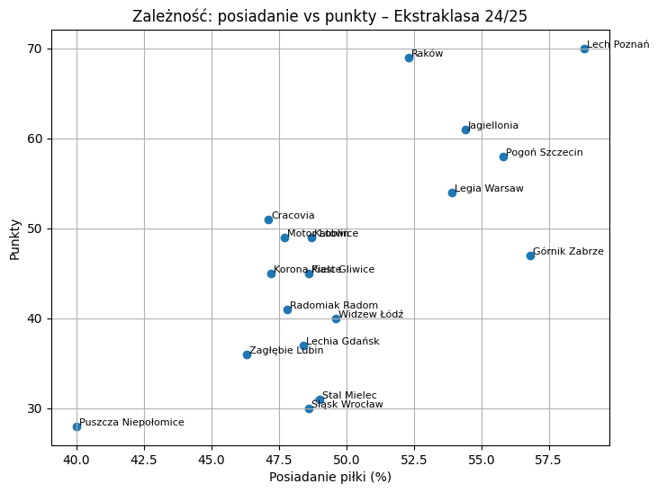

```python
import matplotlib.pyplot as plt

plt.figure(figsize=(8,6))
plt.scatter(df['Poss'], df['Pts'])

for _, row in df.iterrows():
    plt.text(row['Poss'] + 0.1, row['Pts'] + 0.1, row['Squad'], fontsize=8)

plt.xlabel("Posiadanie piłki (%)")
plt.ylabel("Punkty")
plt.title("Zależność: posiadanie vs punkty – Ekstraklasa 24/25")
plt.grid(True)
plt.show()
```

Wykres rozrzutu pokazał, że choć drużyny z górnej części tabeli częściej utrzymywały się przy piłce, zależność ta nie jest silnie deterministyczna. Lech i Raków, znajdujące się w prawym-górnym obszarze wykresu, łączą wysokie posiadanie piłki z dużą liczbą punktów, jednak Górnik mimo jednego z najwyższych poziomów posiadania plasuje się znacznie niżej. Z drugiej strony Puszcza, utrzymująca się przy piłce najrzadziej, zdobyła zdecydowanie najmniej punktów. Wskazuje to na to, że posiadanie piłki może pełnić funkcję wspierającą, lecz nie jest kluczowym czynnikiem decydującym o wynikach.

## Macierz korelacji

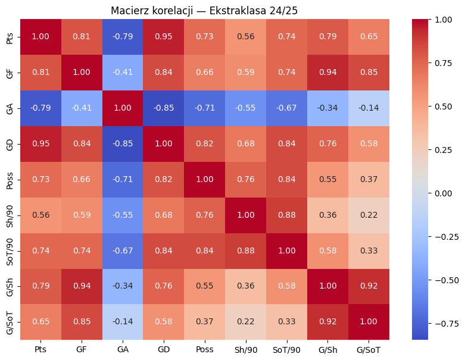

```python
import seaborn as sns
import matplotlib.pyplot as plt

corr = df[['Pts','GF','GA','GD','Poss','Sh/90','SoT/90','G/Sh','G/SoT']].corr()

plt.figure(figsize=(10,7))
sns.heatmap(corr, annot=True, cmap='coolwarm', fmt='.2f')
plt.title("Macierz korelacji — Ekstraklasa 24/25")
plt.show()
```

```python
corr['Pts'].sort_values(ascending=False)
```

```
Pts       1.000000
GD        0.952504
GF        0.809482
G/Sh      0.789049
SoT/90    0.742636
Poss      0.732407
G/SoT     0.648018
Sh/90     0.564860
GA       -0.792966
Name: Pts, dtype: float64
```

## Skuteczność strzałów

```python
df[['Squad','G/Sh','G/SoT']].sort_values(by='G/Sh', ascending=False)
```

|  | Squad | G/Sh | G/SoT |
| --- | --- | --- | --- |
| 0 | Lech Poznań | 0.12 | 0.34 |
| 1 | Raków | 0.10 | 0.28 |
| 2 | Jagiellonia | 0.10 | 0.33 |
| 3 | Pogoń Szczecin | 0.10 | 0.28 |
| 4 | Legia Warsaw | 0.10 | 0.30 |
| 5 | Cracovia | 0.10 | 0.34 |
| 6 | Motor Lublin | 0.10 | 0.32 |
| 7 | Katowice | 0.09 | 0.27 |
| 13 | Lechia Gdańsk | 0.09 | 0.27 |
| 11 | Radomiak Radom | 0.09 | 0.29 |
| 12 | Widzew Łódź | 0.08 | 0.27 |
| 8 | Górnik Zabrze | 0.08 | 0.25 |
| 17 | Puszcza Niepołomice | 0.08 | 0.26 |
| 9 | Piast Gliwice | 0.07 | 0.22 |
| 10 | Korona Kielce | 0.07 | 0.23 |
| 15 | Stal Mielec | 0.07 | 0.21 |
| 16 | Śląsk Wrocław | 0.07 | 0.24 |
| 14 | Zagłębie Lubin | 0.06 | 0.20 |

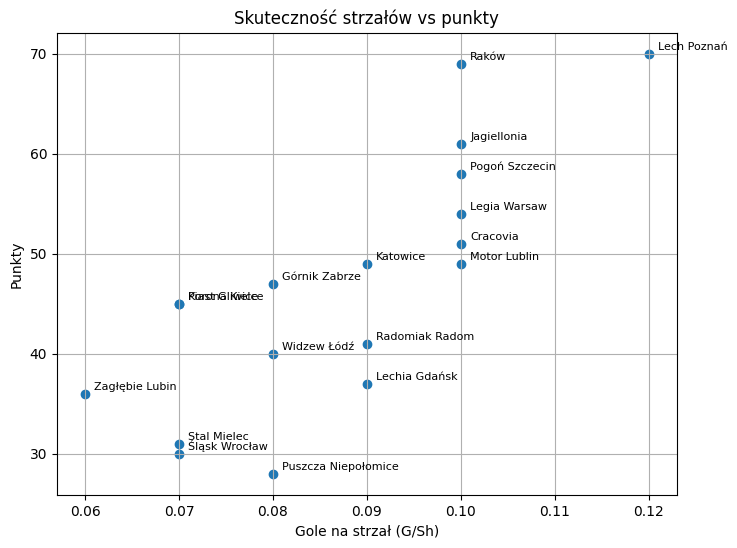

```python
plt.figure(figsize=(8,6))
plt.scatter(df['G/Sh'], df['Pts'])

for _,row in df.iterrows():
    plt.text(row['G/Sh']+0.001, row['Pts']+0.4, row['Squad'], fontsize=8)

plt.xlabel("Gole na strzał (G/Sh)")
plt.ylabel("Punkty")
plt.title("Skuteczność strzałów vs punkty")
plt.grid(True)
plt.show()
```

Czołówka tabeli przeważa w skuteczności oddawanych strzałów, co faktycznie pokazuje ich znaczenie. Drużyny z końca tabeli zajmują raczej końcowe miejsca w rankingu skuteczności strzałów.

## Ranking drużyn w kluczowych metrykach

### Ranking ofensywy (gole strzelone)

```python
df[['Squad','GF']].sort_values('GF', ascending=False)
```

|  | Squad | GF |
| --- | --- | --- |
| 0 | Lech Poznań | 68 |
| 4 | Legia Warsaw | 60 |
| 3 | Pogoń Szczecin | 59 |
| 5 | Cracovia | 58 |
| 2 | Jagiellonia | 56 |
| 1 | Raków | 51 |
| 7 | Katowice | 49 |
| 6 | Motor Lublin | 48 |
| 11 | Radomiak Radom | 48 |
| 13 | Lechia Gdańsk | 44 |
| 8 | Górnik Zabrze | 43 |
| 15 | Stal Mielec | 39 |
| 16 | Śląsk Wrocław | 38 |
| 12 | Widzew Łódź | 38 |
| 9 | Piast Gliwice | 37 |
| 10 | Korona Kielce | 37 |
| 17 | Puszcza Niepołomice | 37 |
| 14 | Zagłębie Lubin | 33 |

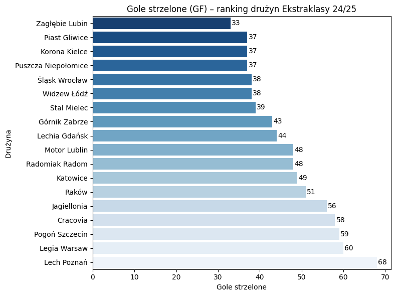

```python
df_offense = df[['Squad', 'GF']].sort_values('GF', ascending=True)  # ascending=True, bo zrobimy poziomy wykres

plt.figure(figsize=(8,6))
sns.barplot(
    data=df_offense,
    x='GF',
    y='Squad',
    hue='Squad',
    palette='Blues_r',
    legend=False
)

plt.title("Gole strzelone (GF) – ranking drużyn Ekstraklasy 24/25")
plt.xlabel("Gole strzelone")
plt.ylabel("Drużyna")

# dodanie wartości na słupkach
for i, v in enumerate(df_offense['GF']):
    plt.text(v + 0.3, i, str(v), va='center')

plt.tight_layout()
plt.show()
```

### Ranking defensywy (gole stracone)

```python
df[['Squad','GA']].sort_values('GA', ascending=True)
```

|  | Squad | GA |
| --- | --- | --- |
| 1 | Raków | 23 |
| 0 | Lech Poznań | 31 |
| 9 | Piast Gliwice | 36 |
| 8 | Górnik Zabrze | 39 |
| 3 | Pogoń Szczecin | 40 |
| 2 | Jagiellonia | 42 |
| 4 | Legia Warsaw | 45 |
| 10 | Korona Kielce | 45 |
| 7 | Katowice | 47 |
| 12 | Widzew Łódź | 49 |
| 14 | Zagłębie Lubin | 51 |
| 11 | Radomiak Radom | 52 |
| 5 | Cracovia | 53 |
| 16 | Śląsk Wrocław | 53 |
| 15 | Stal Mielec | 56 |
| 6 | Motor Lublin | 59 |
| 13 | Lechia Gdańsk | 59 |
| 17 | Puszcza Niepołomice | 63 |

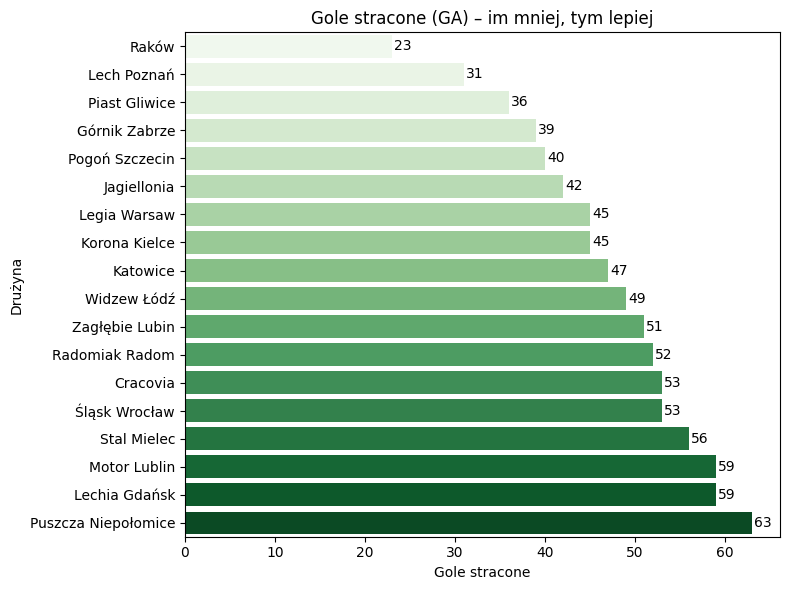

```python
df_defense = df[['Squad', 'GA']].sort_values('GA', ascending=True)  # od najlepszej obrony

plt.figure(figsize=(8,6))
sns.barplot(
    data=df_defense,
    x='GA',
    y='Squad',
    hue='Squad',
    palette='Greens',
    legend=False
)

plt.title("Gole stracone (GA) – im mniej, tym lepiej")
plt.xlabel("Gole stracone")
plt.ylabel("Drużyna")

for i, v in enumerate(df_defense['GA']):
    plt.text(v + 0.3, i, str(v), va='center')

plt.tight_layout()
plt.show()
```

### Ranking strzałów

```python
df[['Squad','Sh/90','SoT/90']].sort_values('Sh/90', ascending=False)
```

|  | Squad | Sh/90 | SoT/90 |
| --- | --- | --- | --- |
| 0 | Lech Poznań | 15.62 | 5.38 |
| 4 | Legia Warsaw | 15.29 | 5.06 |
| 3 | Pogoń Szczecin | 15.09 | 5.29 |
| 8 | Górnik Zabrze | 14.76 | 4.82 |
| 7 | Katowice | 14.68 | 4.62 |
| 14 | Zagłębie Lubin | 14.47 | 4.38 |
| 16 | Śląsk Wrocław | 14.38 | 4.18 |
| 2 | Jagiellonia | 14.12 | 4.47 |
| 11 | Radomiak Radom | 14.00 | 4.21 |
| 5 | Cracovia | 13.85 | 4.29 |
| 1 | Raków | 13.79 | 4.82 |
| 15 | Stal Mielec | 13.50 | 4.18 |
| 9 | Piast Gliwice | 13.41 | 4.21 |
| 10 | Korona Kielce | 13.26 | 3.97 |
| 6 | Motor Lublin | 13.21 | 4.09 |
| 13 | Lechia Gdańsk | 12.53 | 4.18 |
| 12 | Widzew Łódź | 12.47 | 3.56 |
| 17 | Puszcza Niepołomice | 11.00 | 3.44 |

[figure not shown]

```python
df_eff = df[['Squad', 'G/Sh']].sort_values('G/Sh', ascending=True)

plt.figure(figsize=(8,6))
sns.barplot(
    data=df_offense,
    x='GF',
    y='Squad',
    hue='Squad',
    palette='Blues_r',
    legend=False
)


plt.title("Skuteczność strzałów (Gole na strzał – G/Sh)")
plt.xlabel("Gole na strzał (G/Sh)")
plt.ylabel("Drużyna")

for i, v in enumerate(df_eff['G/Sh']):
    plt.text(v + 0.001, i, f"{v:.3f}", va='center')

plt.tight_layout()
plt.show()
```

[figure not shown]

```python
df_eff_sot = df[['Squad', 'G/SoT']].sort_values('G/SoT', ascending=True)

plt.figure(figsize=(8,6))
sns.barplot(
    data=df_offense,
    x='GF',
    y='Squad',
    hue='Squad',
    palette='Blues_r',
    legend=False
)


plt.title("Skuteczność strzałów celnych (Gole na strzał celny – G/SoT)")
plt.xlabel("Gole na strzał celny (G/SoT)")
plt.ylabel("Drużyna")

for i, v in enumerate(df_eff_sot['G/SoT']):
    plt.text(v + 0.005, i, f"{v:.3f}", va='center')

plt.tight_layout()
plt.show()
```

### Ranking posiadania

```python
df[['Squad','Poss']].sort_values('Poss', ascending=False)
```

|  | Squad | Poss |
| --- | --- | --- |
| 0 | Lech Poznań | 58.8 |
| 8 | Górnik Zabrze | 56.8 |
| 3 | Pogoń Szczecin | 55.8 |
| 2 | Jagiellonia | 54.4 |
| 4 | Legia Warsaw | 53.9 |
| 1 | Raków | 52.3 |
| 12 | Widzew Łódź | 49.6 |
| 15 | Stal Mielec | 49.0 |
| 7 | Katowice | 48.7 |
| 9 | Piast Gliwice | 48.6 |
| 16 | Śląsk Wrocław | 48.6 |
| 13 | Lechia Gdańsk | 48.4 |
| 11 | Radomiak Radom | 47.8 |
| 6 | Motor Lublin | 47.7 |
| 10 | Korona Kielce | 47.2 |
| 5 | Cracovia | 47.1 |
| 14 | Zagłębie Lubin | 46.3 |
| 17 | Puszcza Niepołomice | 40.0 |

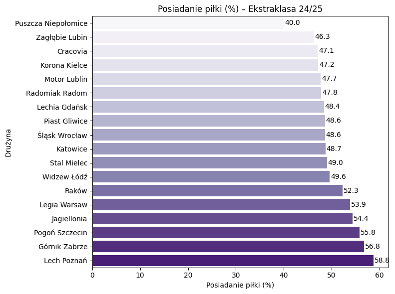

```python
df_poss = df[['Squad', 'Poss']].sort_values('Poss', ascending=True)

plt.figure(figsize=(8,6))
sns.barplot(
    data=df_poss,
    x='Poss',
    y='Squad',
    hue='Squad',
    palette='Purples',
    legend=False
)

plt.title("Posiadanie piłki (%) – Ekstraklasa 24/25")
plt.xlabel("Posiadanie piłki (%)")
plt.ylabel("Drużyna")

for i, v in enumerate(df_poss['Poss']):
    plt.text(v + 0.2, i, f"{v:.1f}", va='center')

plt.tight_layout()
plt.show()
```

## Porównanie grup top4, Mid, Bottom 3

```python
# Dodanie podziału na grupy (Top 4, Mid, Bottom 3)
def tier(rk):
    if rk <= 4:
        return "Top 4"
    elif rk >= 16:
        return "Bottom 3"
    else:
        return "Mid"

df['Tier'] = df['Rk'].apply(tier)
df['Tier'].value_counts()
```

```
Tier
Mid         11
Top 4        4
Bottom 3     3
Name: count, dtype: int64
```

### Porównanie statystyk między grupami

```python
metrics = [
    'Pts', 'GF', 'GA', 'GD', 'Poss',
    'Sh/90', 'SoT/90', 'G/Sh', 'G/SoT'
]

df.groupby('Tier')[metrics].mean().round(2)
```

| Tier | Pts | GF | GA | GD | Poss | Sh/90 | SoT/90 | G/Sh | G/SoT |
| --- | --- | --- | --- | --- | --- | --- | --- | --- | --- |
| Bottom 3 | 29.67 | 38.0 | 57.33 | -19.33 | 45.87 | 12.96 | 3.93 | 0.07 | 0.24 |
| Mid | 44.91 | 45.0 | 48.64 | -3.64 | 49.28 | 13.81 | 4.31 | 0.08 | 0.27 |
| Top 4 | 64.50 | 58.5 | 34.00 | 24.50 | 55.32 | 14.66 | 4.99 | 0.11 | 0.31 |

Statystyki opisowe wyglądają zgodnie z logiką, czyli im wyższa grupa w tabeli tym lepsza średnia z wyników poszczególnych zmiennych.

### Radar chart top4 vs mid vs bottom 3

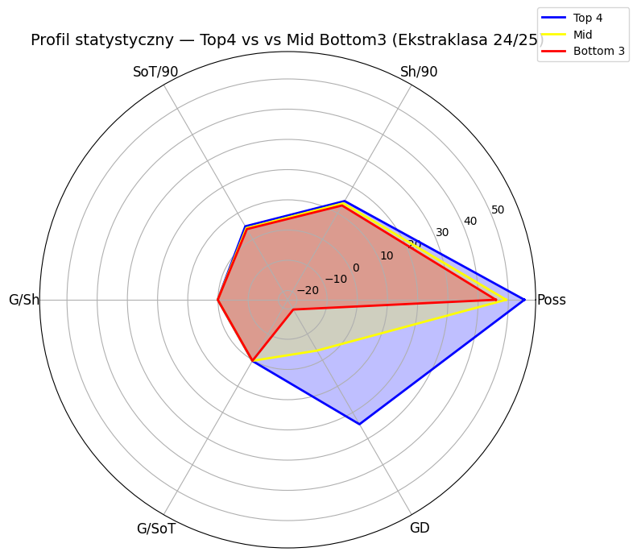

```python
import numpy as np
import matplotlib.pyplot as plt

# Średnie dla grup
top4 = df[df['Tier'] == 'Top 4'][['Poss','Sh/90','SoT/90','G/Sh','G/SoT','GD']].mean()
Mid = df[df['Tier'] == 'Mid'][['Poss','Sh/90','SoT/90','G/Sh','G/SoT','GD']].mean()
bottom3 = df[df['Tier'] == 'Bottom 3'][['Poss','Sh/90','SoT/90','G/Sh','G/SoT','GD']].mean()

# Kategorie
categories = ['Poss', 'Sh/90', 'SoT/90', 'G/Sh', 'G/SoT', 'GD']
N = len(categories)

# Konwersja do list + zamknięcie wykresu (pierwsza wartość = ostatnia)
top4_vals = top4.tolist()
Mid_vals = Mid.tolist()
bottom3_vals = bottom3.tolist()

top4_vals += top4_vals[:1]
Mid_vals += Mid_vals[:1]
bottom3_vals += bottom3_vals[:1]

# Kąty
angles = np.linspace(0, 2 * np.pi, N, endpoint=False).tolist()
angles += angles[:1]

# Wykres
plt.figure(figsize=(8,8))
plt.subplot(111, polar=True)

# Top4
plt.plot(angles, top4_vals, label='Top 4', linewidth=2, color='blue')
plt.fill(angles, top4_vals, alpha=0.25, color='blue')

#Mid
plt.plot(angles, Mid_vals, label='Mid', linewidth=2, color='yellow')
plt.fill(angles, Mid_vals, alpha=0.25, color='yellow')

# Bottom3
plt.plot(angles, bottom3_vals, label='Bottom 3', linewidth=2, color='red')
plt.fill(angles, bottom3_vals, alpha=0.25, color='red')

# Ustawienia
plt.xticks(angles[:-1], categories, fontsize=12)
plt.title("Profil statystyczny — Top4 vs vs Mid Bottom3 (Ekstraklasa 24/25)", fontsize=14)
plt.legend(loc='upper right', bbox_to_anchor=(1.2, 1.1))
plt.show()
```

Zespoły z czołówki cechują się zdecydowanie większą intensywnością ataku: częściej utrzymują się przy piłce, dłużej kontrolują przebieg meczu i regularnie znajdują się na połowie przeciwnika. Drużyny ze strefy spadkowej odstają nie tylko pod względem liczby kreowanych okazji, ale również pod względem stabilności defensywnej. Strata dużej liczby bramek oraz częste błędy w obronie sprawiają, że zespoły te rzadko mają możliwość narzucenia własnego stylu gry, a wiele ich akcji kończy się zanim zdążą stworzyć realne zagrożenie. Dlatego widać zależność co do miejsca w tabeli w przypadku posiadania piłki i różnicy bramek.

## Charakterystyki drużyn: Lech Poznań vs Widzew Łódź

```python
lech = df[df['Squad'] == 'Lech Poznań']
widzew = df[df['Squad'] == 'Widzew Łódź']

stats = ['Poss','Sh/90','SoT/90','G/Sh','G/SoT','GF','GA','GD','Pts']

comparison = pd.DataFrame({
    'Statystyka': stats,
    'Lech Poznań': lech[stats].iloc[0].values,
    'Widzew Łódź': widzew[stats].iloc[0].values
})

comparison
```

|  | Statystyka | Lech Poznań | Widzew Łódź |
| --- | --- | --- | --- |
| 0 | Poss | 58.80 | 49.60 |
| 1 | Sh/90 | 15.62 | 12.47 |
| 2 | SoT/90 | 5.38 | 3.56 |
| 3 | G/Sh | 0.12 | 0.08 |
| 4 | G/SoT | 0.34 | 0.27 |
| 5 | GF | 68.00 | 38.00 |
| 6 | GA | 31.00 | 49.00 |
| 7 | GD | 37.00 | -11.00 |
| 8 | Pts | 70.00 | 40.00 |

### Wykres RADAR (Lech vs Widzew)

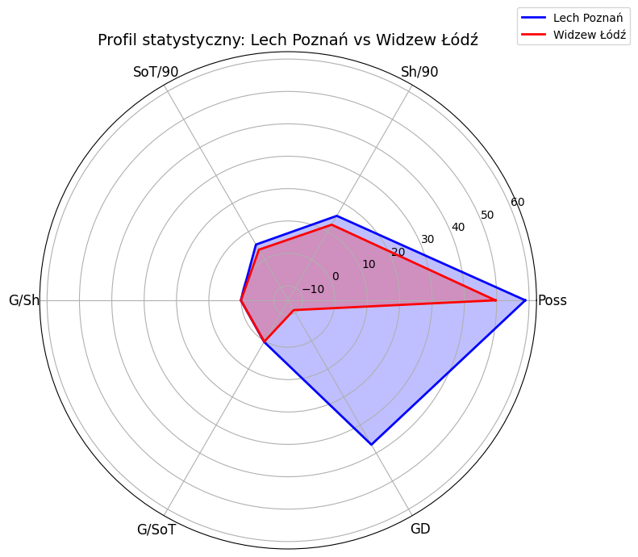

```python
import numpy as np
import matplotlib.pyplot as plt

# wartości
lech_vals = lech[['Poss','Sh/90','SoT/90','G/Sh','G/SoT','GD']].iloc[0].values.tolist()
widzew_vals = widzew[['Poss','Sh/90','SoT/90','G/Sh','G/SoT','GD']].iloc[0].values.tolist()

categories = ['Poss','Sh/90','SoT/90','G/Sh','G/SoT','GD']
N = len(categories)

# domknięcie wykresu
lech_plot = lech_vals + lech_vals[:1]
widzew_plot = widzew_vals + widzew_vals[:1]

angles = np.linspace(0, 2*np.pi, N, endpoint=False).tolist()
angles += angles[:1]

plt.figure(figsize=(8,8))
plt.subplot(111, polar=True)

# Lech
plt.plot(angles, lech_plot, label='Lech Poznań', linewidth=2, color='blue')
plt.fill(angles, lech_plot, alpha=0.25, color='blue')

# Widzew
plt.plot(angles, widzew_plot, label='Widzew Łódź', linewidth=2, color='red')
plt.fill(angles, widzew_plot, alpha=0.25, color='red')

plt.xticks(angles[:-1], categories, fontsize=12)
plt.title("Profil statystyczny: Lech Poznań vs Widzew Łódź", fontsize=14)
plt.legend(loc='upper right', bbox_to_anchor=(1.2, 1.1))

plt.show()
```

Lech prezentuje profil drużyny dominującej zarówno pod względem stylu gry, jak i efektywności. Utrzymywał jedno z najwyższych w lidze posiadanie piłki, co przekładało się na większą liczbę akcji ofensywnych, dodatnią różnicę barmek oraz znacznie wyższy wolumen strzałów i strzałów celnych. Drużyna Widzewa natomiast generowała mniejszą liczbę strzałów, rzadziej dochodziła do czystych pozycji strzeleckich, miała ujemny bilans bramkowy, a jej posiadanie piłki oscylowało wokół wartości typowych dla zespołów środka tabeli. Studium przypadku jasno pokazuje, że różnica punktowa pomiędzy tymi zespołami nie wynika z jednego, pojedynczego wskaźnika. Jest efektem skumulowanego wpływu wielu elementów, w których Lech konsekwentnie przewyższał swojego rywala.

## Porównanie grup top4, Mid, Bottom 3

```python
# Dodanie podziału na grupy (Top 4, Mid, Bottom 3)
def tier(rk):
    if rk <= 4:
        return "Top 4"
    elif rk >= 16:
        return "Bottom 3"
    else:
        return "Mid"

df['Tier'] = df['Rk'].apply(tier)
df['Tier'].value_counts()
```

```
Tier
Mid         11
Top 4        4
Bottom 3     3
Name: count, dtype: int64
```

### Porównanie statystyk między grupami

```python
metrics = [
    'Pts', 'GF', 'GA', 'GD', 'Poss',
    'Sh/90', 'SoT/90', 'G/Sh', 'G/SoT'
]

df.groupby('Tier')[metrics].mean().round(2)
```

| Tier | Pts | GF | GA | GD | Poss | Sh/90 | SoT/90 | G/Sh | G/SoT |
| --- | --- | --- | --- | --- | --- | --- | --- | --- | --- |
| Bottom 3 | 29.67 | 38.0 | 57.33 | -19.33 | 45.87 | 12.96 | 3.93 | 0.07 | 0.24 |
| Mid | 44.91 | 45.0 | 48.64 | -3.64 | 49.28 | 13.81 | 4.31 | 0.08 | 0.27 |
| Top 4 | 64.50 | 58.5 | 34.00 | 24.50 | 55.32 | 14.66 | 4.99 | 0.11 | 0.31 |

Statystyki opisowe wyglądają zgodnie z logiką, czyli im wyższa grupa w tabeli tym lepsza średnia z wyników poszczególnych zmiennych.

# 3. Predictive Modeling

```python
features = [
    'GF',      # gole strzelone
    'GA',      # gole stracone
    'Poss',    # posiadanie piłki
    'Sh/90',   # strzały na 90
    'SoT/90',  # strzały celne na 90
    'G/Sh',    # skuteczność strzałów
    'G/SoT'    # skuteczność celnych
]

X = df[features]
y = df['Pts']
```

```python
# Standaryzacja
from sklearn.preprocessing import StandardScaler

scaler = StandardScaler()
X_scaled = scaler.fit_transform(X)
```

## model regresji liniowej

```python
from sklearn.linear_model import LinearRegression

model = LinearRegression()
model.fit(X_scaled, y)

model.coef_, model.intercept_
```

```
(array([-0.86930394, -7.63277263, -1.31613059, -0.66830161,  3.43953687,
         1.57335207,  5.56108167]),
 np.float64(46.72222222222222))
```

```python
importance = pd.DataFrame({
    'Feature': features,
    'Coefficient': model.coef_
}).sort_values('Coefficient', ascending=False)

importance
```

|  | Feature | Coefficient |
| --- | --- | --- |
| 6 | G/SoT | 5.561082 |
| 4 | SoT/90 | 3.439537 |
| 5 | G/Sh | 1.573352 |
| 3 | Sh/90 | -0.668302 |
| 0 | GF | -0.869304 |
| 2 | Poss | -1.316131 |
| 1 | GA | -7.632773 |

### R²

```python
from sklearn.metrics import r2_score

y_pred = model.predict(X_scaled)
print("R²:")
r2_score(y, y_pred)
```

```
R²:
```

```
0.9451880698542499
```

94.5% zmienności liczby punktów drużyn w lidze jest wyjaśnione przez zmienne w modelu. Jest to bardzo dobry wynik.

## Przewidywane punkty vs rzeczywiste

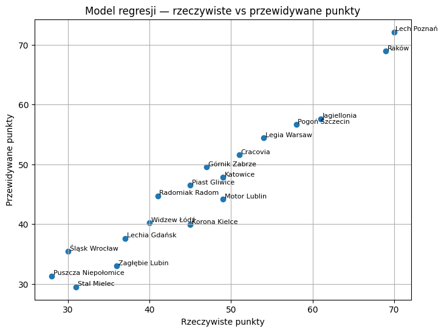

```python
import matplotlib.pyplot as plt

plt.figure(figsize=(8,6))
plt.scatter(y, y_pred)

for i, row in df.iterrows():
    plt.text(row['Pts'] + 0.2, y_pred[i] + 0.2, row['Squad'], fontsize=8)

plt.xlabel("Rzeczywiste punkty")
plt.ylabel("Przewidywane punkty")
plt.title("Model regresji — rzeczywiste vs przewidywane punkty")
plt.grid(True)
plt.show()
```

```python
df['Diff'] = df['Pts'] - df['Predicted_Pts']

df[['Squad', 'Pts', 'Predicted_Pts', 'Diff']].sort_values('Diff', ascending=False)
```

|  | Squad | Pts | Predicted_Pts | Diff |
| --- | --- | --- | --- | --- |
| 10 | Korona Kielce | 45 | 39.920302 | 5.079698 |
| 6 | Motor Lublin | 49 | 44.165639 | 4.834361 |
| 2 | Jagiellonia | 61 | 57.608251 | 3.391749 |
| 14 | Zagłębie Lubin | 36 | 32.998360 | 3.001640 |
| 15 | Stal Mielec | 31 | 29.496075 | 1.503925 |
| 3 | Pogoń Szczecin | 58 | 56.677336 | 1.322664 |
| 7 | Katowice | 49 | 47.797315 | 1.202685 |
| 1 | Raków | 69 | 68.905237 | 0.094763 |
| 12 | Widzew Łódź | 40 | 40.189111 | -0.189111 |
| 4 | Legia Warsaw | 54 | 54.386850 | -0.386850 |
| 5 | Cracovia | 51 | 51.606787 | -0.606787 |
| 13 | Lechia Gdańsk | 37 | 37.625374 | -0.625374 |
| 9 | Piast Gliwice | 45 | 46.479511 | -1.479511 |
| 0 | Lech Poznań | 70 | 72.123751 | -2.123751 |
| 8 | Górnik Zabrze | 47 | 49.530769 | -2.530769 |
| 17 | Puszcza Niepołomice | 28 | 31.342878 | -3.342878 |
| 11 | Radomiak Radom | 41 | 44.710584 | -3.710584 |
| 16 | Śląsk Wrocław | 30 | 35.435871 | -5.435871 |

# Key Findings

Najważniejszym z wniosków jest dominująca rola efektywności ofensywnej. Drużyny osiągające wysokie miejsca w tabeli charakteryzowały się nie tylko większą liczbą oddawanych strzałów, ale przede wszystkim wyższą jakością i skutecznością tych prób. Drugim kluczowym wnioskiem jest wyraźna rola organizacji gry defensywnej, czego najlepszym przykładem pozostaje Raków. Jego wysoka pozycja w tabeli była wynikiem przede wszystkim wzorowo funkcjonującej defensywy, która redukowała liczbę strat bramkowych i pozwalała na zdobywanie punktów nawet w meczach o ograniczonej liczbie sytuacji ofensywnych. Model regresji potwierdził wagę tego czynnika, wskazując liczbę straconych bramek jako jedną z najsilniej, negatywnie skorelowanych zmiennych w odniesieniu do punktów. Wreszcie analiza expected points pokazała, że część drużyn uzyskiwała wyniki powyżej lub poniżej potencjału wynikającego ze statystyk.

# Recommendations

Analiza wskazuje, że drużyny z dolnej części tabeli Ekstraklasy powinny przede wszystkim poprawić liczbę tworzonych sytuacji ofensywnych, ponieważ generują zbyt mało okazji do zdobycia bramki. Drugim istotnym obszarem jest organizacja defensywy, ponieważ liczba straconych bramek silnie wpływa na zdobycz punktową drużyn. Poprawa dyscypliny taktycznej, ustawienia w polu karnym oraz zachowania w fazach przejściowych może ograniczyć straty wynikające z błędów indywidualnych i braku asekuracji. Dodatkowo większe wykorzystanie analityki sportowej, w tym analiz expected points, może pomóc drużynom lepiej wykorzystywać swój potencjał i podejmować trafniejsze decyzje taktyczne oraz kadrowe.